# Model Building

Kim Pham

5/18/2019

## Model Building

- predict the likely tip amount for a trip based on the other trip attributes.
- assume ride sharing company can provide data that has the same attributes as the taxi data for each trip.
- model requirements:
  - build model from taxi dataset; supplement external datasets not required
  - document your choice of model / algorithm, discussing why you chose it over alternatives
  - document how you assess your models performance.
    - Discuss any limitations or caveats of the model which might be an issue in implementing it.
    - Discuss how you might improve your model going forward.
  - discuss how you might turn this model in to an API the company can use.

### Model Building Outline

Data Summary: In our exploration we saw most trips are one passenger rides where the average tip is 1.874414 and most passengers paid by credit card. We also saw the type of rate codes that receive the highest tips on average (i.e. Newark, Nassau or Westchester, JFK, and Negotiated Fare) are the trips with the greatest average_distances.

Let’s build a supervised machine learning model and use linear multiple regression with 10 fold cross validation to predict the likely tip amount for a trip. This model makes sense since we are interested in an estimated tip amount and not binary outcomes (where logistic regression would be useful), categorization (where neural nets or random forests would be useful)), or cluster analysis (where kmeans or hierarchical clustering would be useful).

Let’s evaluate what variables would be significant, run the regression, and assess and interpret the results.

### Load libraries

```r
library(dplyr)
library(ggplot2)
library(dummies)
library(caret)
library(leaps)
```

### Load cleaned data set

```r
my_data <- readRDS("data/df.rds") # check dataExploration rmd for cleaned data process
```

### Check variables and process data

```r
str(my_data)
```

```
## Classes 'tbl_df', 'tbl' and 'data.frame':    29120154 obs. of  15 variables:
##  $ VendorID             : num  2 2 2 2 2 2 2 2 2 1 ...
##  $ tpep_pickup_datetime : POSIXct, format: "2017-03-09 21:30:11" "2017-03-09 21:47:00" ...
##  $ tpep_dropoff_datetime: POSIXct, format: "2017-03-09 21:44:20" "2017-03-09 21:58:01" ...
##  $ passenger_count      : num  1 1 1 1 1 1 1 1 5 1 ...
##  $ trip_distance        : num  4.06 2.73 2.27 3.86 3.45 4.21 2.84 0.58 0.4 0.9 ...
##  $ RatecodeID           : num  1 1 1 1 1 1 1 1 1 1 ...
##  $ store_and_fwd_flag   : chr  "N" "N" "N" "N" ...
##  $ payment_type         : num  1 2 1 1 2 1 2 1 1 1 ...
##  $ fare_amount          : num  14 11.5 10 12 12 20.5 12 4.5 4 7 ...
##  $ extra                : num  0.5 0.5 0.5 0.5 0.5 0 0 0 0 0 ...
##  $ mta_tax              : num  0.5 0.5 0.5 0.5 0.5 0.5 0.5 0.5 0.5 0.5 ...
##  $ tip_amount           : num  3.06 0 2.82 3.99 0 4.26 0 1.59 1.2 1.55 ...
##  $ tolls_amount         : num  0 0 0 0 0 0 0 0 0 0 ...
##  $ improvement_surcharge: num  0.3 0.3 0.3 0.3 0.3 0.3 0.3 0.3 0.3 0.3 ...
##  $ total_amount         : num  18.4 12.8 14.1 17.3 13.3 ...
```

```r
my_data <- select(my_data,-tpep_pickup_datetime,-tpep_dropoff_datetime,-store_and_fwd_flag)
# remove pickup and dropoff date time, and store_and_fwd_flag to simply analysis
# logic: population sizes between the different months seem equal; most observations are forwarded not stored and have unequal groupings
my_data$VendorID <- as.factor(my_data$VendorID) # change Vendor ID from numeric to factor
my_data$passenger_count <- as.factor(my_data$passenger_count) # change passenger_count from numeric to factor
my_data$RatecodeID <- as.factor(my_data$RatecodeID) # change RatecodeID from numeric to factor
my_data$payment_type <- as.factor(my_data$payment_type) # change payment_type from numeric to factor
str(my_data)
```

```
## Classes 'tbl_df', 'tbl' and 'data.frame':    29120154 obs. of  12 variables:
##  $ VendorID             : Factor w/ 2 levels "1","2": 2 2 2 2 2 2 2 2 2 1 ...
##  $ passenger_count      : Factor w/ 9 levels "1","2","3","4",..: 1 1 1 1 1 1 1 1 5 1 ...
##  $ trip_distance        : num  4.06 2.73 2.27 3.86 3.45 4.21 2.84 0.58 0.4 0.9 ...
##  $ RatecodeID           : Factor w/ 6 levels "1","2","3","4",..: 1 1 1 1 1 1 1 1 1 1 ...
##  $ payment_type         : Factor w/ 5 levels "1","2","3","4",..: 1 2 1 1 2 1 2 1 1 1 ...
##  $ fare_amount          : num  14 11.5 10 12 12 20.5 12 4.5 4 7 ...
##  $ extra                : num  0.5 0.5 0.5 0.5 0.5 0 0 0 0 0 ...
##  $ mta_tax              : num  0.5 0.5 0.5 0.5 0.5 0.5 0.5 0.5 0.5 0.5 ...
##  $ tip_amount           : num  3.06 0 2.82 3.99 0 4.26 0 1.59 1.2 1.55 ...
##  $ tolls_amount         : num  0 0 0 0 0 0 0 0 0 0 ...
##  $ improvement_surcharge: num  0.3 0.3 0.3 0.3 0.3 0.3 0.3 0.3 0.3 0.3 ...
##  $ total_amount         : num  18.4 12.8 14.1 17.3 13.3 ...
```

```r
# saveRDS(my_data, "data/modeldf.rds")
# my_data <- readRDS("data/modeldf.rds") # restore if needed
# str(my_data)
```

### Run Backward Feature Selection

The backward feature selection will let us observe which variables in our dataset would give us a higher coefficient of determination, or r squared.

```r
# backward feature selection
regsubsets.out <-
   regsubsets(tip_amount~ .,
              data = my_data,
              nbest = 1,       # 1 best model for each number of predictors
              nvmax = NULL,    # NULL for no limit on number of variables
              force.in = NULL, force.out = NULL,
              method = "backward")
# regsubsets.out

summary.out <- summary(regsubsets.out)
df_outmat<-as.data.frame(summary.out$outmat)
df_outmat

plot(regsubsets.out, scale = "adjr2", main = "Adjusted R^2")
```

```r
# backward feature selection
regsubsets.out <-
   regsubsets(tip_amount~ .,
              data = my_data,
              nbest = 1,       # 1 best model for each number of predictors
              nvmax = NULL,    # NULL for no limit on number of variables
              force.in = NULL, force.out = NULL,
              method = "backward")
# regsubsets.out

summary.out <- summary(regsubsets.out)
df_outmat<-as.data.frame(summary.out$outmat)
df_outmat
```

```
##           VendorID2 passenger_count2 passenger_count3 passenger_count4
## 1  ( 1 )
## 2  ( 1 )
## 3  ( 1 )
## 4  ( 1 )
## 5  ( 1 )
## 6  ( 1 )
## 7  ( 1 )          *
## 8  ( 1 )          *
## 9  ( 1 )          *
## 10  ( 1 )         *
## 11  ( 1 )         *
## 12  ( 1 )         *
## 13  ( 1 )         *
## 14  ( 1 )         *
```

[output cut: 141 more lines]

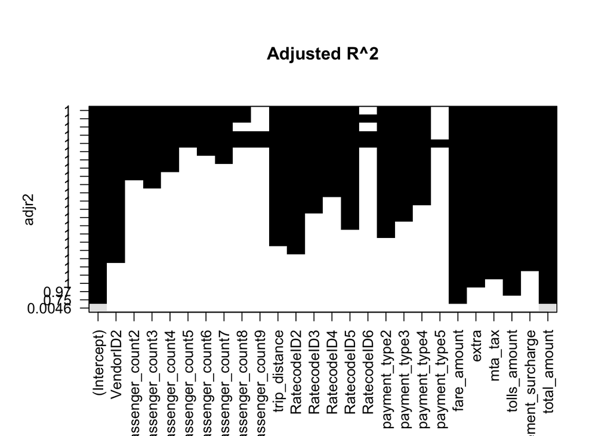

```r
plot(regsubsets.out, scale = "adjr2", main = "Adjusted R^2")
```

Based off the plot, let’s use the least amount of variables in our regression model that would give us the greatest adjusted r squared: fare_amount, extra, tolls_amount, and total_amount.

### Run multiple linear regression model

```r
# narrow dataframe to allow quicker computation
set.seed(1029)
new_df<-my_data[sample(nrow(my_data), 50000), ]
```

```r
# split train test data set 75, 25
set.seed(1280)
tax_index <- createDataPartition(new_df$tip_amount, p = .75, list = FALSE)
tax_tr <- new_df[ tax_index, ]
tax_te <- new_df[-tax_index, ]

# set 10 fold cross fold validation parameters
fitControl <- trainControl(method = "repeatedcv", number = 10, repeats = 5)

# run regression
set.seed(6278)
lm_fit <- train(tip_amount ~ fare_amount+extra+tolls_amount+total_amount,
               data = tax_tr,
               method = "lm",
               trControl = fitControl)
```

#### Model results

```r
lm_fit$finalModel # print coefficients
```

```
##
## Call:
## lm(formula = .outcome ~ ., data = dat)
##
## Coefficients:
##  (Intercept)   fare_amount         extra  tolls_amount  total_amount
##      -0.8351       -0.9856       -0.8300       -0.9768        0.9866
```

#### Model assessment

```r
summary(lm_fit) # print regression results
```

```
##
## Call:
## lm(formula = .outcome ~ ., data = dat)
##
## Residuals:
##     Min      1Q  Median      3Q     Max
## -31.948  -0.039   0.026   0.057   4.155
##
## Coefficients:
##                Estimate Std. Error t value Pr(>|t|)
## (Intercept)  -0.8350619  0.0020960  -398.4   <2e-16 ***
## fare_amount  -0.9855841  0.0006178 -1595.3   <2e-16 ***
## extra        -0.8300477  0.0024268  -342.0   <2e-16 ***
## tolls_amount -0.9767654  0.0011133  -877.4   <2e-16 ***
## total_amount  0.9866434  0.0005431  1816.6   <2e-16 ***
## ---
## Signif. codes:  0 '***' 0.001 '**' 0.01 '*' 0.05 '.' 0.1 ' ' 1
##
## Residual standard error: 0.2263 on 37497 degrees of freedom
## Multiple R-squared:  0.9926, Adjusted R-squared:  0.9926
## F-statistic: 1.265e+06 on 4 and 37497 DF,  p-value: < 2.2e-16
```

```r
tax_pred <- predict(lm_fit, tax_te) # predict model results on test set
postResample(pred = tax_pred, obs = tax_te$tip_amount) # assess
```

```
##       RMSE   Rsquared        MAE
## 0.13428262 0.99717398 0.06278837
```

Overall, our model includes variables that account for high variance in our outcome variable, the tip_amount. The variables we selected are statistically significant predictors of our outcome variable. Furthermore, the root mean square error and mean absolute error resulting from running model on our test set is low, which is good since we want our residuals low where the fitted line is close to the actual values.

#### Model Limitations

We ran our model on a subset of the entire data set due to computing power limitations. Furthermore, there are other variable we left out. It would be worth while to validate our results by seeing if our results are reproducible using a larger subset of the entire data set to train and test the models on.

### Model Improvements

- It would be interesting to run logistic regression and categorize those who will tip and those will not tip. Even more, before running regression, it would be interesting to run clustering techniques like kmeans or hierarchical clustering to differentiate groups of cab passengers (e.g. those who use cabs to go to JFK or Newark versus those who pay in cash). We could subset our current dataset which is heavily skewed towards specific profiles and see if we get different regression model results.